# SDS 192 Mini Project 1

Group I: Irene Xu, De’Andra Graham, Neamat Sabry

2/17/19

```r
library(tidyverse)
library(fivethirtyeight)
library(ggthemes)
data("hate_crimes")
```

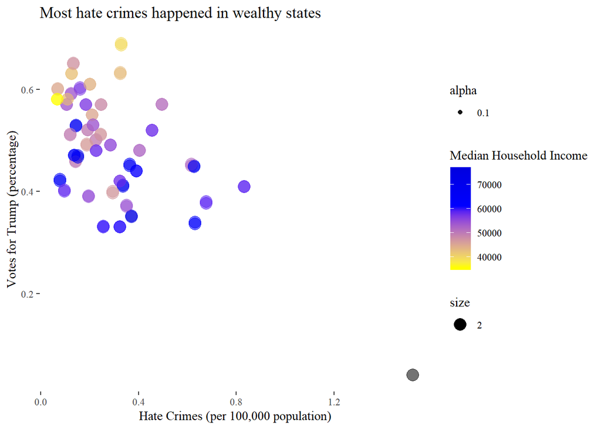

```r
crimes <- hate_crimes %>%
  filter(hate_crimes_per_100k_splc <= 1)
dc <- hate_crimes %>%
  filter(hate_crimes_per_100k_splc >= 1)

state_crimes_plot <- ggplot(crimes, aes(x = hate_crimes_per_100k_splc, y = share_vote_trump, color = median_house_inc, size = 2, alpha = 0.1)) +
  geom_point(data = dc, aes(color = NULL)) +
  geom_point() +
  geom_jitter() +
  labs(x = "Hate Crimes (per 100,000 population)",
       y = "Votes for Trump (percentage)",
       title = "Most hate crimes happened in wealthy states") +
  scale_color_gradient2("Median Household Income", high = "blue3", low = "yellow", mid = "blue", midpoint = 61000) +
  theme_tufte()

state_crimes_plot
```

## Data Analysis

fivethirtyeight package: Hate_crimes dataset

Every dot represents a state and its position explains its corresponding x and y value, as well as its relative position in the dataset. There is one state, Washington DC, that is an outlier with an exceptionally high MHI and number of hate crimes, so we didn’t include it in the color mapping. We interpreted that this high rate of hate crimes in DC is due to the extreme political tension after the election in the capital.

Overall, MHI is negatively associated with voting for Trump and is roughly positively associated with occurences of hate crimes (especially when the occurrences of hate crimes are higher). Surprisingly, the correlation between the voting rate for Trump and the occurrences of hate crimes was negative and weak. Some of the states with low MHI also have the least diversity, a variable that was included in the dataset but wasn’t added to our data graphic. However, there is a potential problem with the data: more hate crimes were reported with, as the researchers explained, “heightened news coverage of hate incidents” after the elections.